# HEIDI: Marian

**Institution Profile**

**Classification:** Special Focus: Medical Schools and Centers

**Size:** Medium

**Award Level Focus:** Undergraduate/Graduate-Doctorate

**UG Program Mix:** Special Focus: Medical Schools and Centers

**Grad Program Mix:** Special Focus: Medical Schools and Centers

**Research Activity:** Research Colleges and Universities

**Student Access & Earnings:** Not Classified in SAEC

**Location**

[interactive chart not shown]

#### Higher Education Institutional Data Interface (HEIDI)

HEIDI is a dashboard tool created by the Casagrande Institute to report data for institutions of higher education.

#### Casagrande Institute

The [Casagrande Institute](https://www.viterbo.edu/casagrande-institute/) helps institutions develop effective compensation practices for executives, faculty, and staff.

[figure not shown]

**David J. Bauer, Ph.D.**  
Director, Casagrande Institute  
djbauer@viterbo.edu  
608-796-3617  
[LinkedIn](https://www.linkedin.com/in/davidjbauer/)

**Group Overview**

- **A: Recommended Benchmark Group**: Group of institutions recommended for Marian University (IN) compensation benchmarking. Private NFP, Expenses $100M - $300M, Total FTE 3,000 - 8,000, and the following Carnegie classifications: Professions-focused Undergraduate/Graduate-Doctorate Large, Professions-focused Undergraduate/Graduate-Doctorate Medium, Professions-focused Undergraduate/Graduate-Doctorate Small, Special Focus: Medical Schools and Centers, Special Focus: Nursing, Special Focus: Other Health Professions. Based on IPEDS data from 2024-25.
- **B: Osteo Benchmark Group**: Group of Private NFP institutions with Expenses up to $500M that satisfy one or more of the following criteria: 1. membership in the American Association of Colleges of Osteopathic Medicine (AACOM) institutions in 2026, 2. membership in the Commission on Osteopathic College Accreditation (COCA) institutions in 2026, or 3. a 2025 Carnegie classification of “Special Focus: Medical Schools and Centers”. Excludes institutions in Puerto Rico.

**Group Membership**

| Institution | A: Recommended Benchmark Group | B: Osteo Benchmark Group |
| --- | --- | --- |
| A T Still University of Health Sciences | ✓ | ✓ |
| Abilene Christian University | ✓ |  |
| Adelphi University | ✓ |  |
| Alabama College of Osteopathic Medicine |  | ✓ |
| Arkansas Colleges of Health Education |  | ✓ |
| Ashland University | ✓ |  |
| Aurora University | ✓ |  |
| Azusa Pacific University | ✓ |  |
| Baptist Health Sciences University |  | ✓ |
| Barry University | ✓ |  |

[output cut: 73 more lines]

**A: Recommended Benchmark Group**

| Name | City | State | Zip | Carnegie | Research | Revenue | Expenses | FTE | Endowment |
| --- | --- | --- | --- | --- | --- | --- | --- | --- | --- |
| A T Still University of Health Sciences | Kirksville | MO | 63501 | Special Focus: Medical Schools and Centers | No research designation | 246784177 | 189842485 | 3923 | 136425451 |
| Abilene Christian University | Abilene | TX | 79699 | Professions-focused Undergraduate/Graduate-Doctorate Medium | Research 2: High Spending and Doctorate Production | 260122634 | 190781908 | 4646 | 821879729 |
| Adelphi University | Garden City | NY | 11530 | Professions-focused Undergraduate/Graduate-Doctorate Medium | No research designation | 252844732 | 228836757 | 7013 | 255623639 |
| Ashland University | Ashland | OH | 44805 | Professions-focused Undergraduate/Graduate-Doctorate Medium | No research designation | 115102763 | 111481329 | 3238 | 71414534 |
| Aurora University | Aurora | IL | 60506 | Professions-focused Undergraduate/Graduate-Doctorate Medium | No research designation | 107725831 | 102583862 | 6076 | 54014375 |
| Azusa Pacific University | Azusa | CA | 91702 | Professions-focused Undergraduate/Graduate-Doctorate Medium | Research 2: High Spending and Doctorate Production | 172761130 | 179107795 | 6332 | 96232956 |
| Barry University | Miami | FL | 33161 | Professions-focused Undergraduate/Graduate-Doctorate Medium | No research designation | 145502184 | 143555499 | 5601 | 58752320 |
| Bradley University | Peoria | IL | 61625 | Professions-focused Undergraduate/Graduate-Doctorate Medium | No research designation | 180828719 | 162898147 | 4765 | 362421752 |
| Butler University | Indianapolis | IN | 46208 | Professions-focused Undergraduate/Graduate-Doctorate Medium | No research designation | 264680000 | 238398000 | 6203 | 297229000 |
| Campbell University | Buies Creek | NC | 27506 | Professions-focused Undergraduate/Graduate-Doctorate Medium | No research designation | 186676855 | 161912512 | 5172 | 210406971 |

[output cut: 45 more lines]

**B: Osteo Benchmark Group**

| Name | City | State | Zip | Carnegie | Research | Revenue | Expenses | FTE | Endowment |
| --- | --- | --- | --- | --- | --- | --- | --- | --- | --- |
| A T Still University of Health Sciences | Kirksville | MO | 63501 | Special Focus: Medical Schools and Centers | No research designation | 246784177 | 189842485 | 3923 | 136425451 |
| Alabama College of Osteopathic Medicine | Dothan | AL | 36303 | Special Focus: Medical Schools and Centers | No research designation | 48551065 | 35147162 | 799 | 217663 |
| Arkansas Colleges of Health Education | Fort Smith | AR | 72916 | Special Focus: Medical Schools and Centers | No research designation | 57982168 | 47269642 | 907 | 6636048 |
| Baptist Health Sciences University | Memphis | TN | 38104 | Special Focus: Nursing | No research designation | 34109038 | 30432074 | 622 | 91778586 |
| Campbell University | Buies Creek | NC | 27506 | Professions-focused Undergraduate/Graduate-Doctorate Medium | No research designation | 186676855 | 161912512 | 5172 | 210406971 |
| Charles R Drew University of Medicine and Science | Los Angeles | CA | 90059 | Special Focus: Medical Schools and Centers | Research Colleges and Universities | 95118100 | 96581000 | 1197 | 109922800 |
| D'Youville University | Buffalo | NY | 14201 | Special Focus: Other Health Professions | No research designation | 86480172 | 95298826 | 2412 | 22307551 |
| Des Moines University-Osteopathic Medical Center | West Des Moines | IA | 50266 | Special Focus: Medical Schools and Centers | Research Colleges and Universities | 99479413 | 89508356 | 1639 | 177057947 |
| Duquesne University | Pittsburgh | PA | 15282 | Professions-focused Undergraduate/Graduate-Doctorate Medium | Research 2: High Spending and Doctorate Production | 382314000 | 323172000 | 8122 | 661012000 |
| Edward Via College of Osteopathic Medicine | Blacksburg | VA | 24060 | Special Focus: Medical Schools and Centers | Research Colleges and Universities | 153360525 | 120866047 | 2615 | 31210043 |

[output cut: 29 more lines]

**A: Recommended Benchmark Group**

**Financial and Student Positioning of Marian Within the A: Recommended Benchmark Group Group**

| Metric | **A: Recommended Benchmark Group Group** n | **A: Recommended Benchmark Group Group** Min | **A: Recommended Benchmark Group Group** p25 | **A: Recommended Benchmark Group Group** Median | **A: Recommended Benchmark Group Group** p75 | **A: Recommended Benchmark Group Group** Max | Spread | **Marian** Marian | **Marian** Percentile | **Marian** % of Median |
| --- | --- | --- | --- | --- | --- | --- | --- | --- | --- | --- |
| Revenue | 54 | 100.9M | 125.7M | 174.4M | 233.4M | 403.1M |  | 173.2M | 49 | 99% |
| Expenses | 54 | 101.3M | 124.1M | 154.9M | 188.8M | 293.8M |  | 141.5M | 43 | 91% |
| Margin | 54 | −17.7M | 3.8M | 15.7M | 30.0M | 145.9M |  | 31.7M | 80 | 202% |
| Endowment | 54 | 3.2M | 75.2M | 137.3M | 251.3M | 821.9M |  | 126.9M | 45 | 92% |
| Avg Net Price | 49 | 13.2k | 22.8k | 27.2k | 31.9k | 50.0k |  | 22.8k | 25 | 84% |
| Avg Net Price + 0.04 * Endowment / UG FTE | 49 | 13.9k | 24.4k | 28.9k | 34.9k | 53.1k |  | 24.6k | 27 | 85% |
| 12-Month Unduplicated Headcount | 54 | 3,191 | 5,001 | 5,770 | 6,928 | 12,807 |  | 4,696 | 20 | 81% |
| Undergrad FTE | 50 | 10 | 2,501 | 3,223 | 4,017 | 5,429 |  | 2,872 | 41 | 89% |
| Grad FTE | 54 | 412 | 745 | 965 | 1,379 | 2,805 |  | 518 | 6 | 54% |
| Doc Prof Prac FTE | 47 | 32 | 202 | 420 | 1,206 | 3,941 |  | 679 | 67 | 162% |
| Total FTE | 54 | 3,191 | 3,933 | 4,652 | 6,099 | 7,866 |  | 4,069 | 30 | 87% |
| Student-to-Faculty Ratio | 50 | 2 | 11 | 12 | 14 | 21 |  | 13 | 67 | 108% |
| Undergrad Pell % | 50 | 0 | 22 | 29 | 35 | 70 |  | 29 | 50 | 100% |

Data from IPEDS for the 2024-25 academic year. Group values exclude data from Marian.

**B: Osteo Benchmark Group**

**Financial and Student Positioning of Marian Within the B: Osteo Benchmark Group Group**

[output not shown]

Data from IPEDS for the 2024-25 academic year. Group values exclude data from Marian.

**A: Recommended Benchmark Group**

**Revenue**

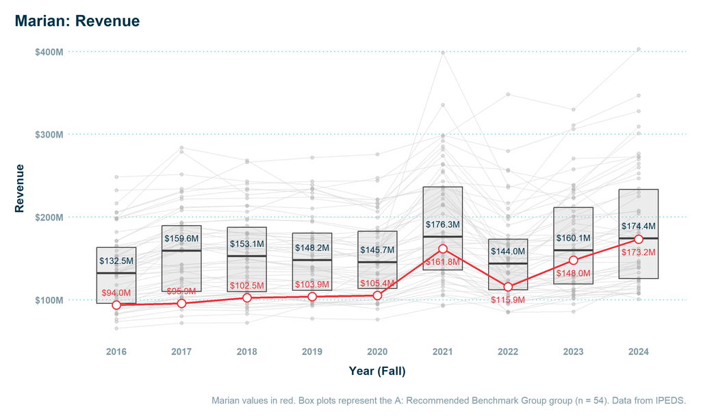

**Expenses**

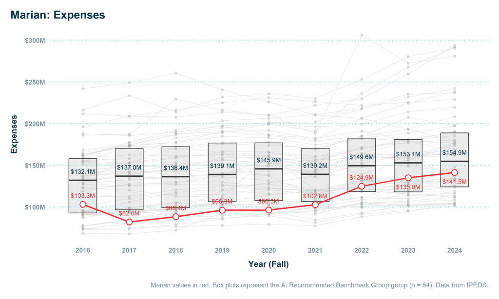

**Margin**

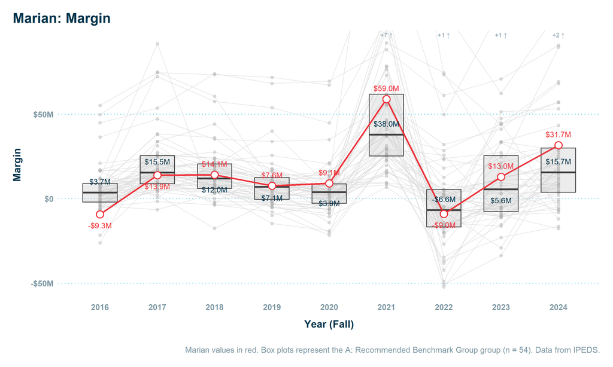

**Endowment**

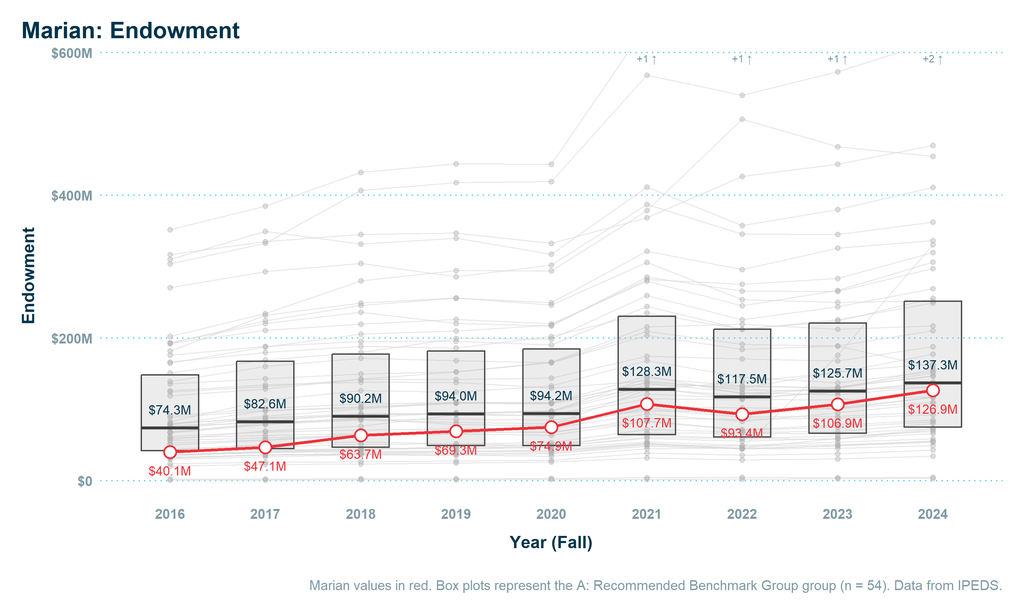

**Avg Net Price**

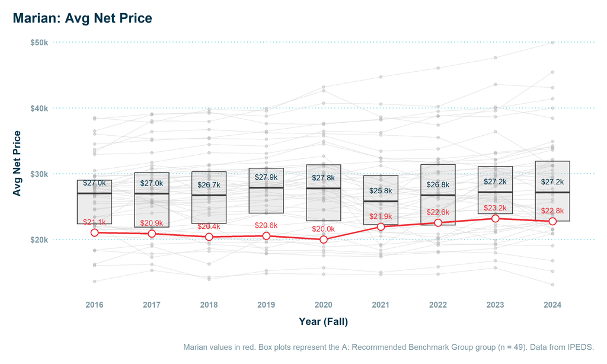

**Avg Net Price + 0.04 * Endowment / UG FTE**

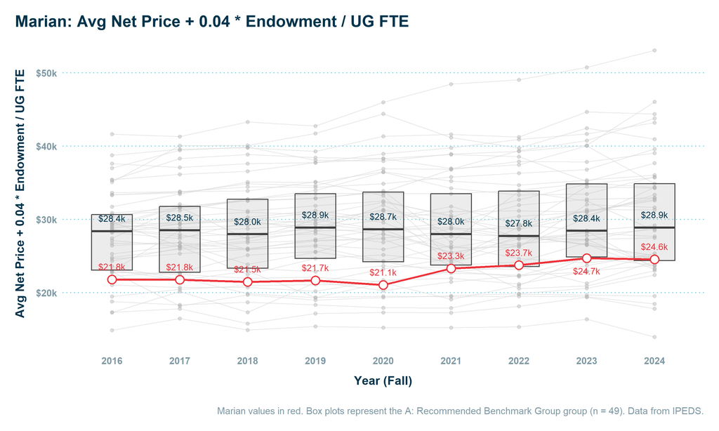

**12-Month Unduplicated Headcount**

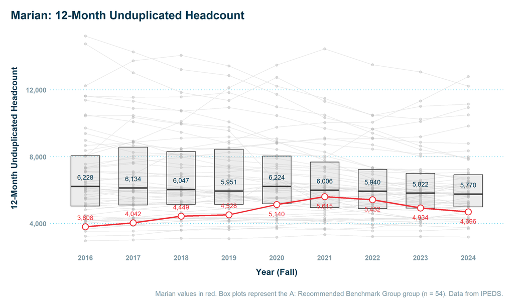

**Undergrad FTE**

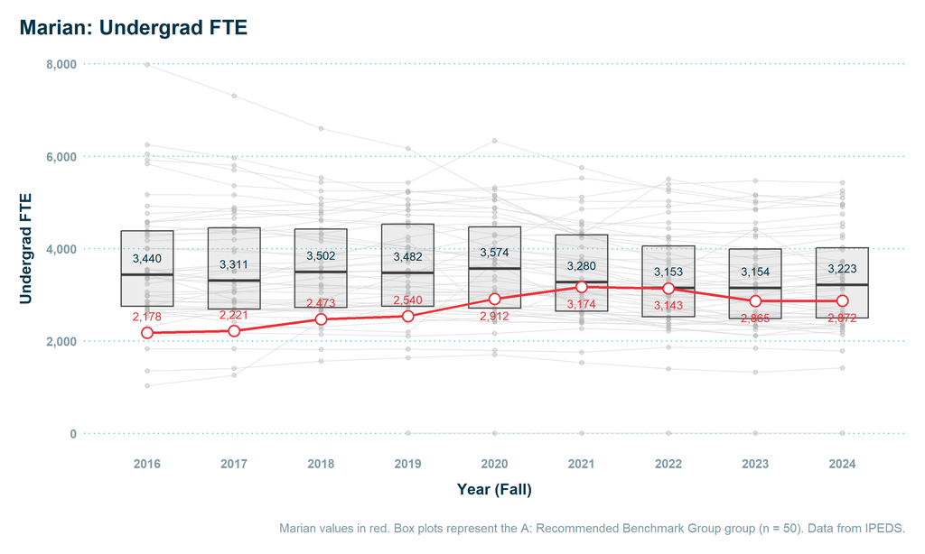

**Grad FTE**

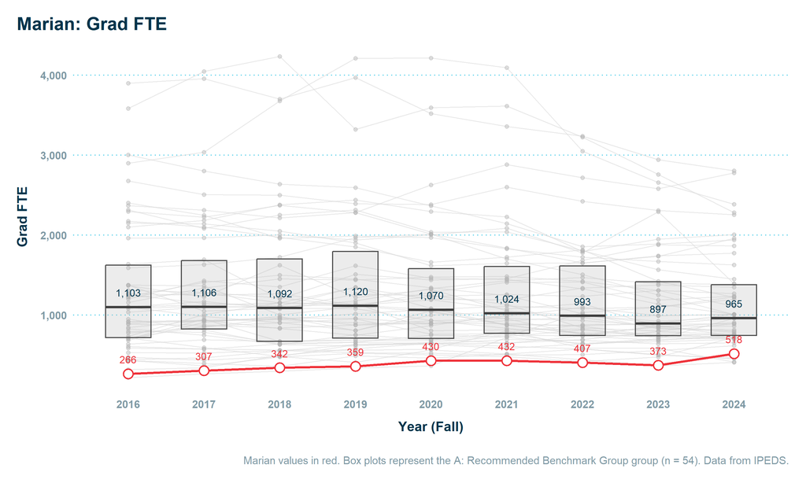

**Doc Prof Prac FTE**

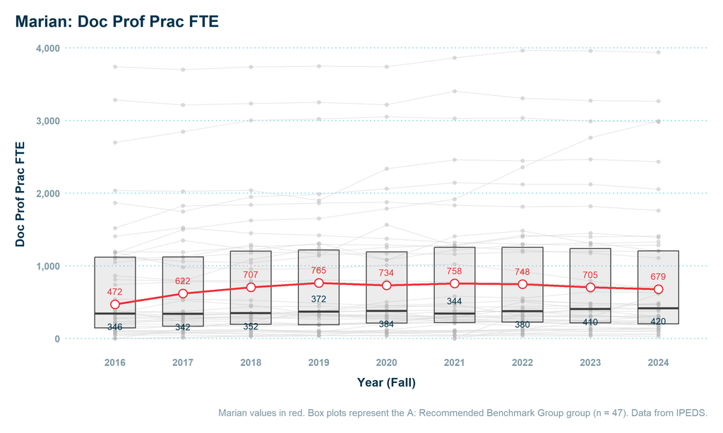

**Total FTE**

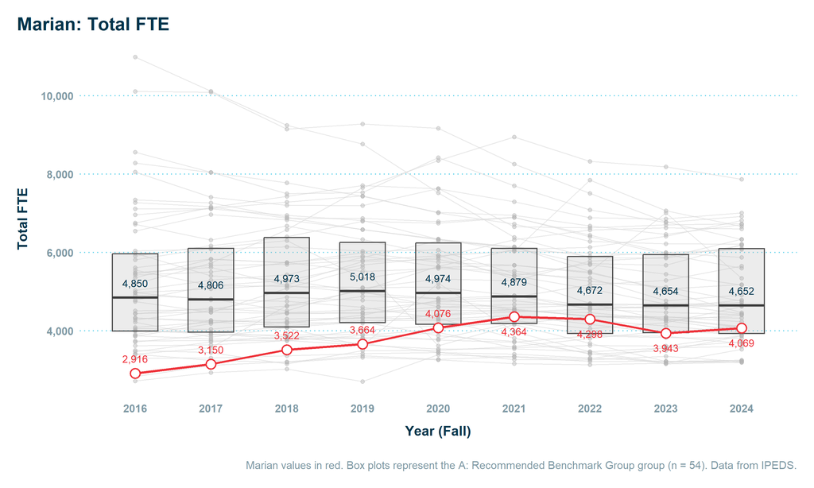

**Student-to-Faculty Ratio**

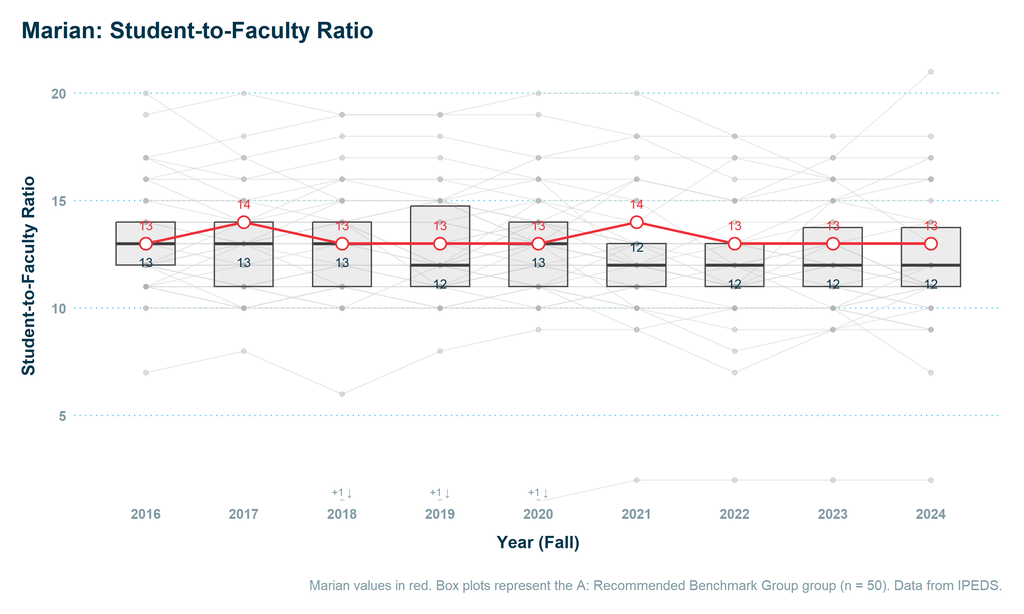

**Undergrad Pell %**

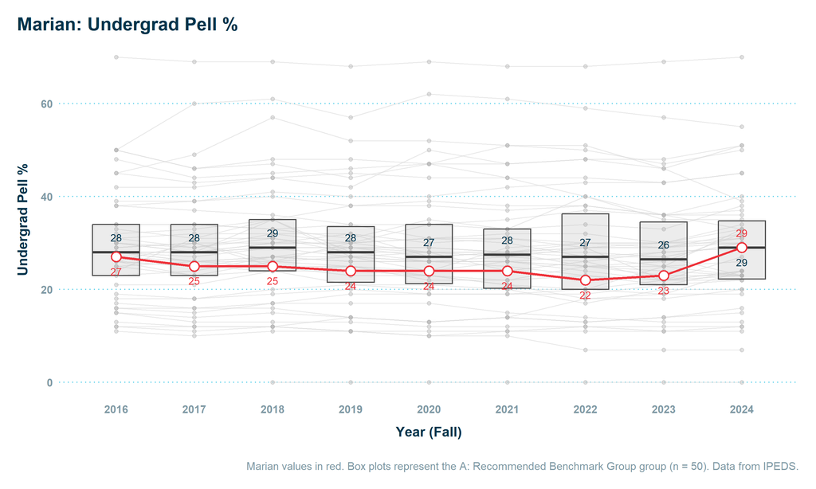

**B: Osteo Benchmark Group**

**Revenue**

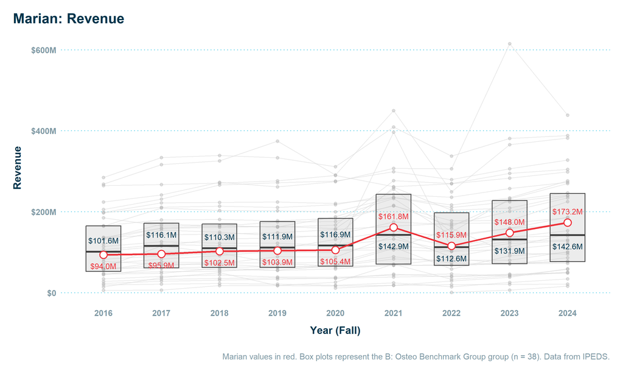

**Expenses**

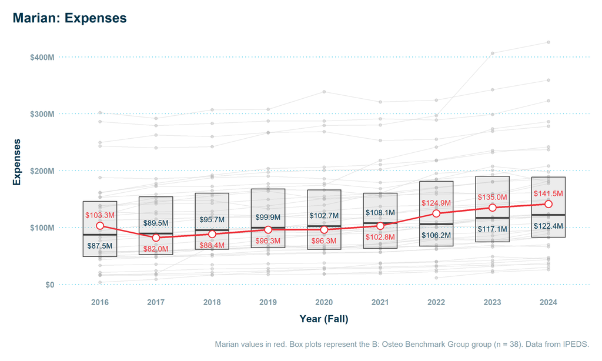

**Margin**

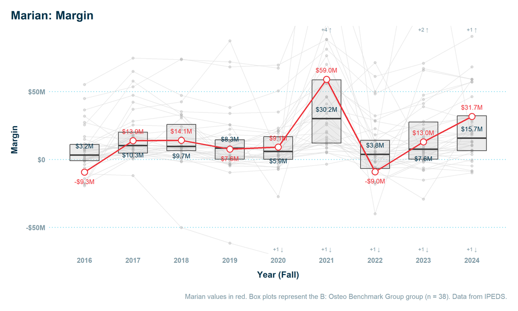

**Endowment**

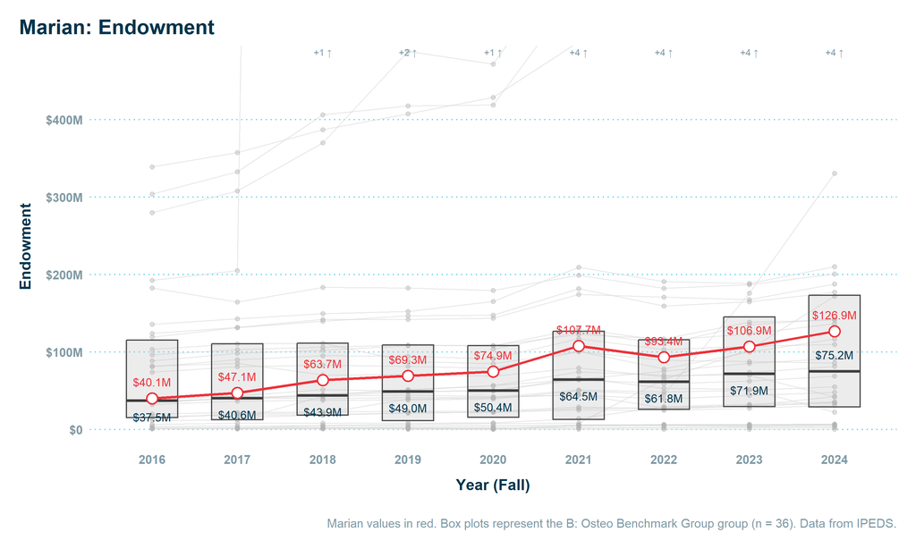

**Avg Net Price**

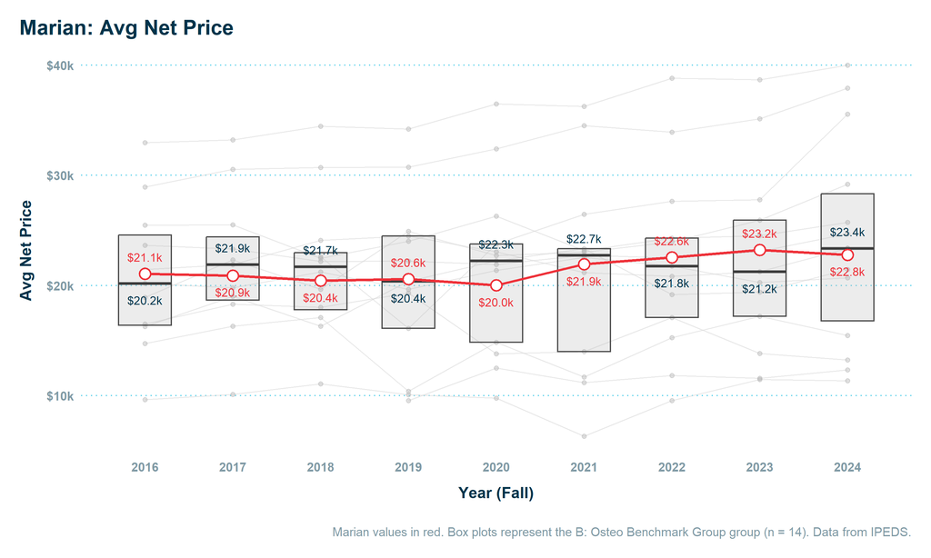

**Avg Net Price + 0.04 * Endowment / UG FTE**

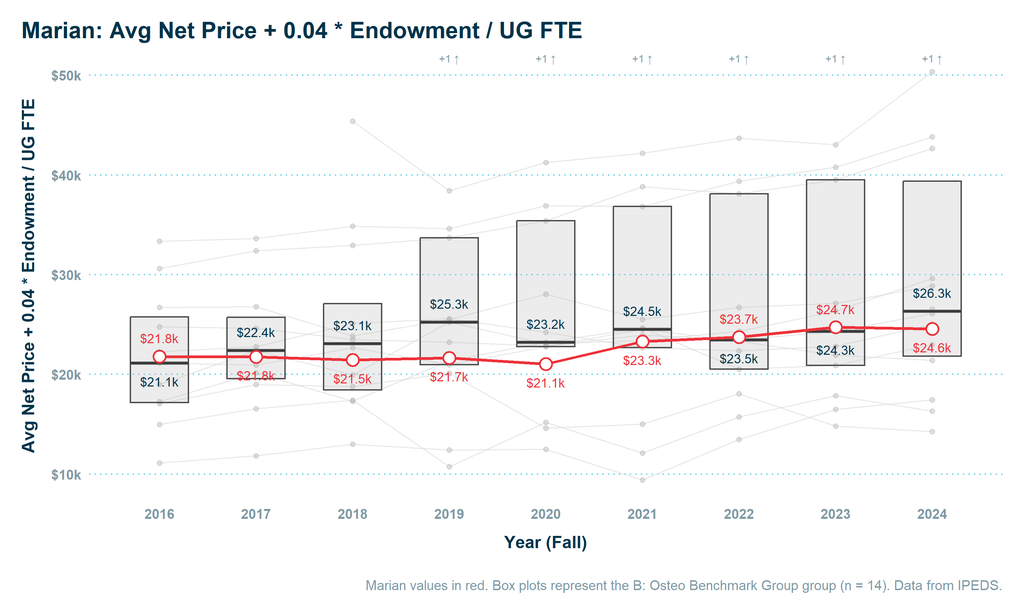

**12-Month Unduplicated Headcount**

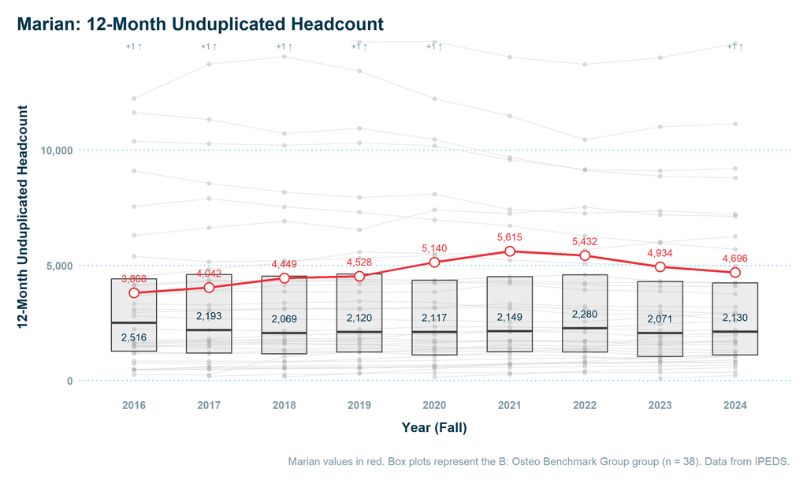

**Undergrad FTE**

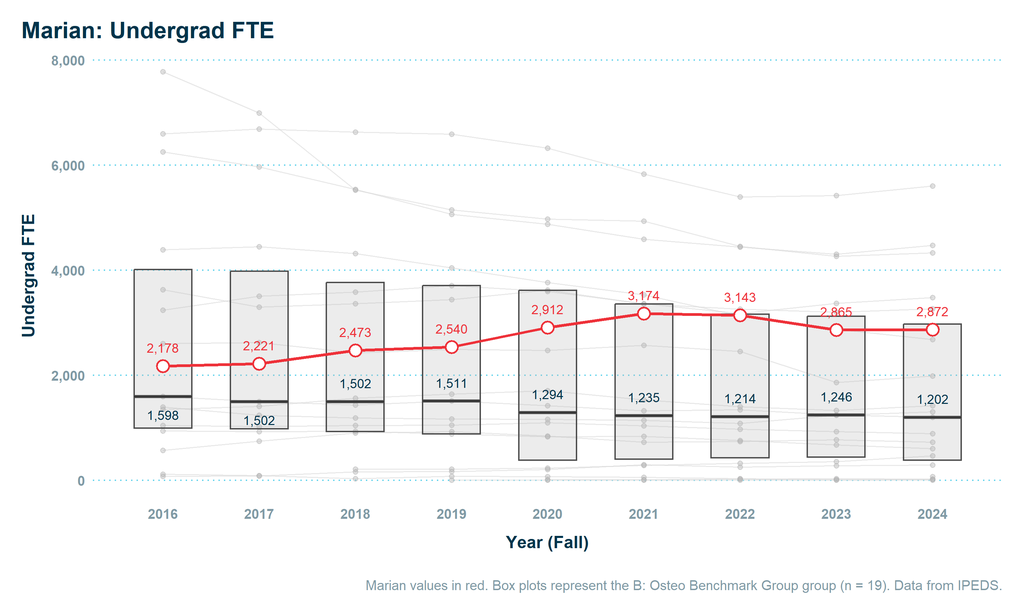

**Grad FTE**

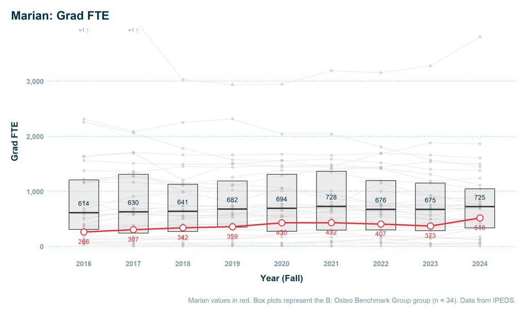

**Doc Prof Prac FTE**

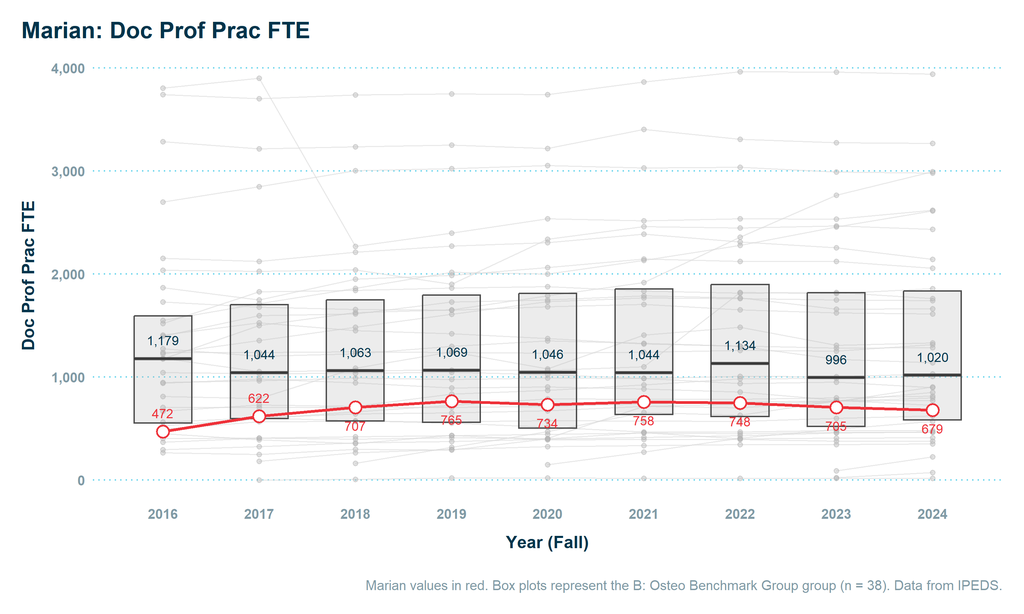

**Total FTE**

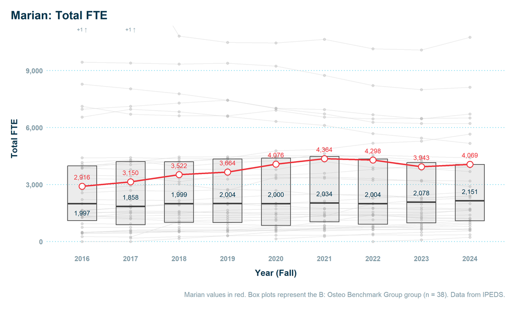

**Student-to-Faculty Ratio**

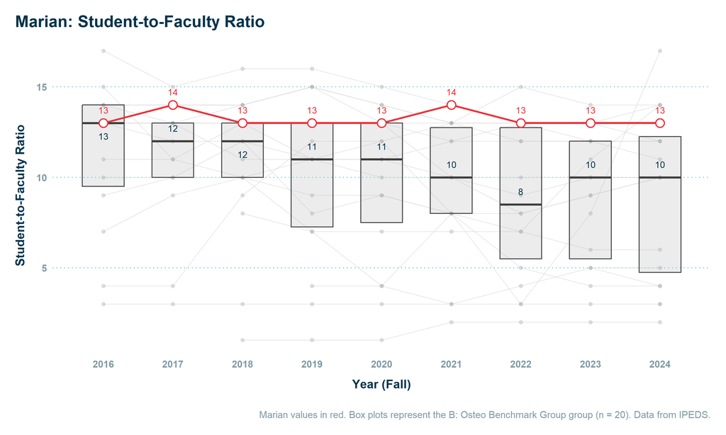

**Undergrad Pell %**

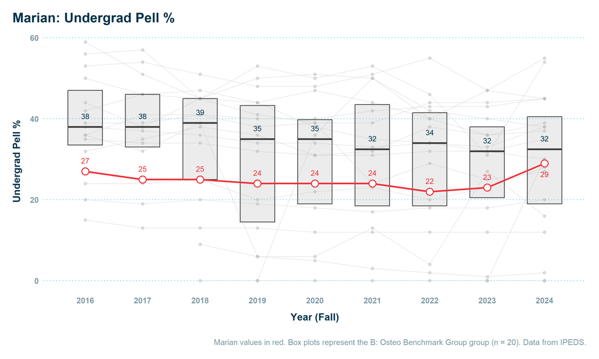

**A: Recommended Benchmark Group**

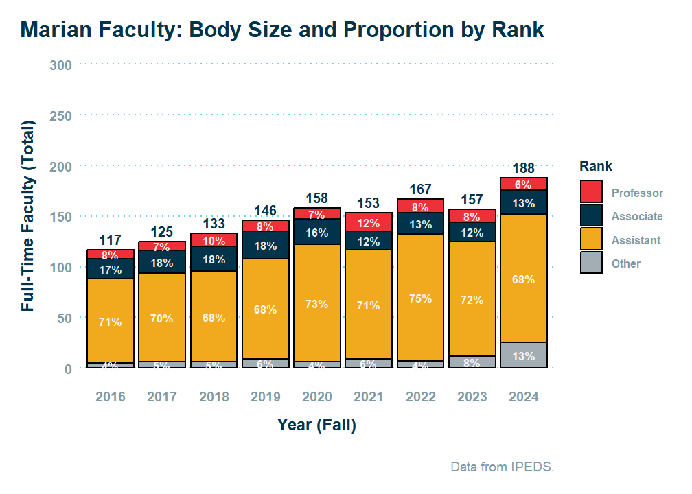

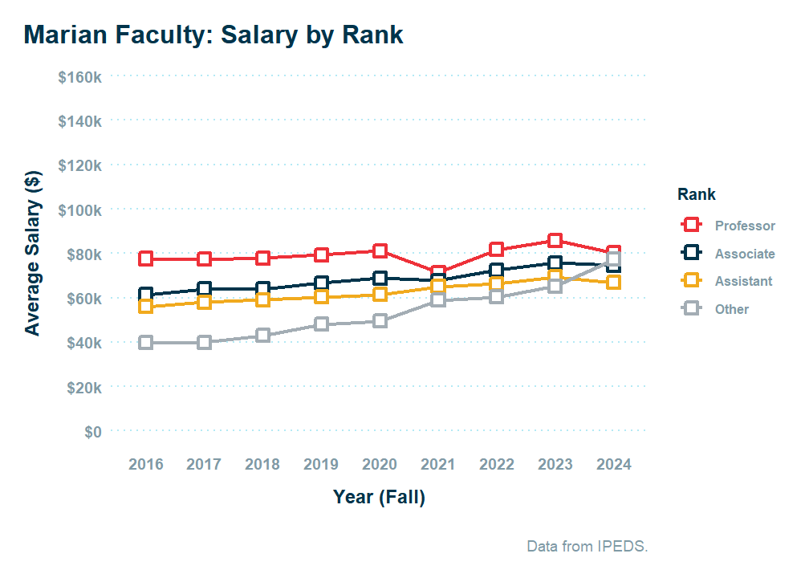

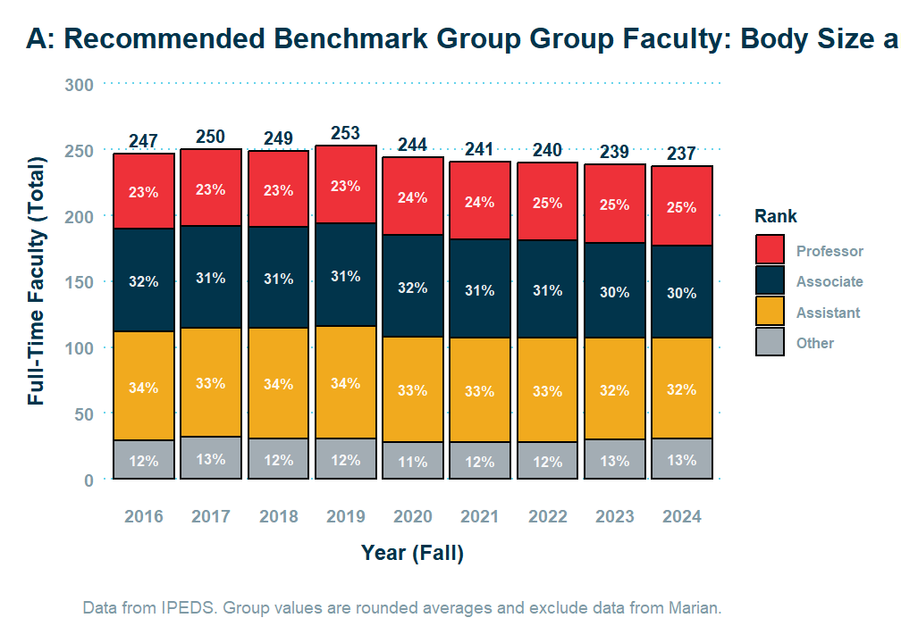

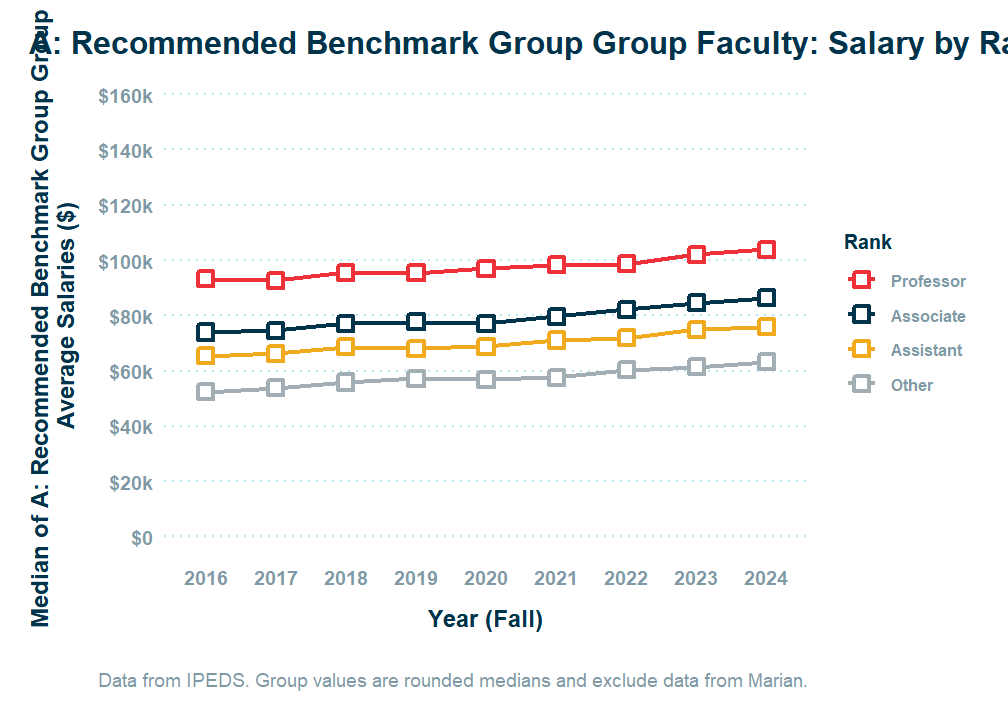

**B: Osteo Benchmark Group**

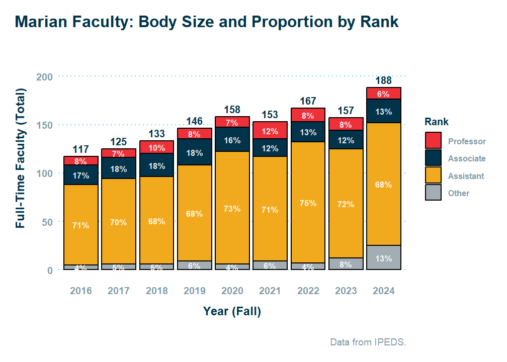

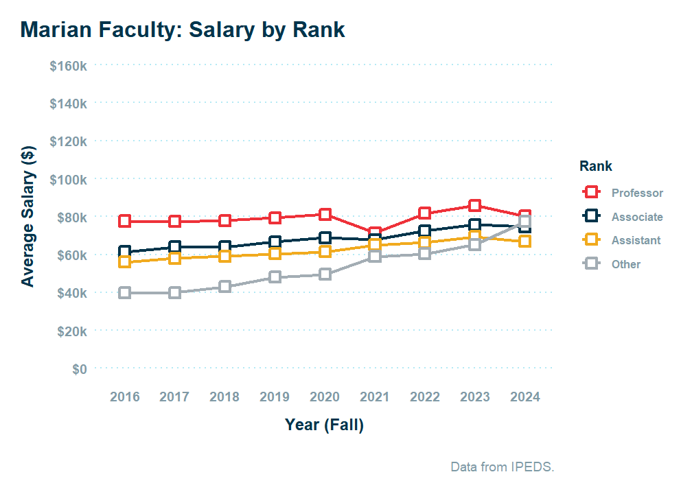

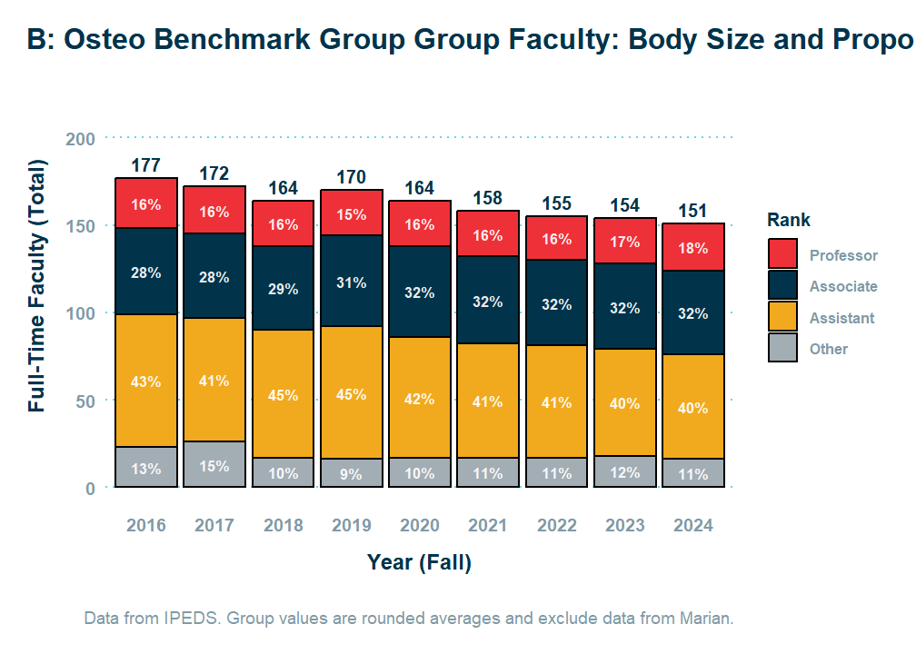

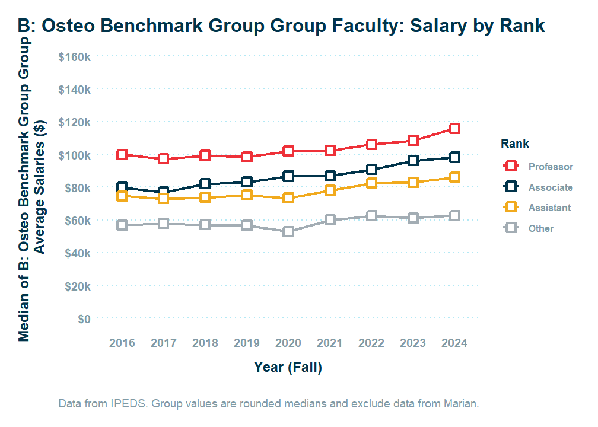